# Making QA masks from a Landsat 8 scene with unpackqa

```python
import rasterio
from matplotlib import pyplot as plt
import numpy as np

import unpackqa
```

```python
L8_QA_PIXEL_FILE = '/home/shawn/projects/unpackqa/docs/examples_dev/LC08_L2SP_140041_20130503_20200912_02_T1_QA_PIXEL.TIF'
# This is the product code internal to unpackqa only.
L8_qa_product = 'LANDSAT_8_C2_L2_QAPixel'

# Load the QA raster as a numpy array.
with rasterio.open(L8_QA_PIXEL_FILE) as src:
    img_qa_data = src.read(1)


def quick_raster_plot(img_data, title='', legend=False, unique_values=[0,1]):
    plt.figure(figsize = (8,8))
    plt.title(title)
    plt.imshow(img_data)
    if legend:
        plt.colorbar(ticks=unique_values,values=unique_values, fraction=0.03)
```

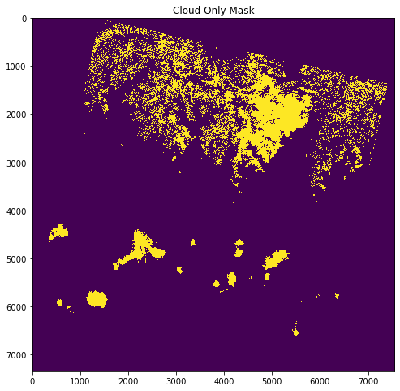

```python
cloud_only_mask = unpackqa.unpack_to_array(img_qa_data,
                                             product=L8_qa_product,
                                             flags=['Cloud'])

quick_raster_plot(cloud_only_mask, title='Cloud Only Mask')
```

Along with clouds you probably also want to mask cloud shadows. It's possible to pull both those masks at once and combine them for a single mask.

Here the `cloud_and_shadow_mask` array has an added axis at the end, with length 2, representing the 2 masks. Next those 2 axis are summed, so that any value > 0 represents a pixel with either a cloud or cloud shadow

```python
cloud_and_shadow_mask = unpackqa.unpack_to_array(img_qa_data,
                                                   product=L8_qa_product,
                                                   flags=['Cloud','Cloud_Shadow'])
print('Original Scene Shape: {}'.format(img_qa_data.shape))
print('Cloud and Shadow mask shape: {}'.format(cloud_and_shadow_mask.shape))
```

```
Original Scene Shape: (7351, 7551)
Cloud and Shadow mask shape: (7351, 7551, 2)
```

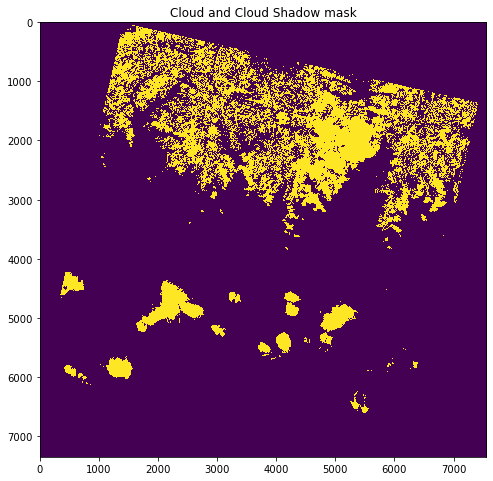

```python
cloud_and_shadow_mask = cloud_and_shadow_mask.sum(axis=-1) > 0
quick_raster_plot(cloud_and_shadow_mask, title='Cloud and Cloud Shadow mask')
```

Most QA bands are binary (either 0 or 1) but some have more values. Here the Cloud Confidence QA flag can take the following values.

- 0 : for no confidence level set
- 1 : Low confidence
- 2 : Medium confidence
- 3 : High confidence

These can be plotted as well to show the variation in cloud confidence across the scene.

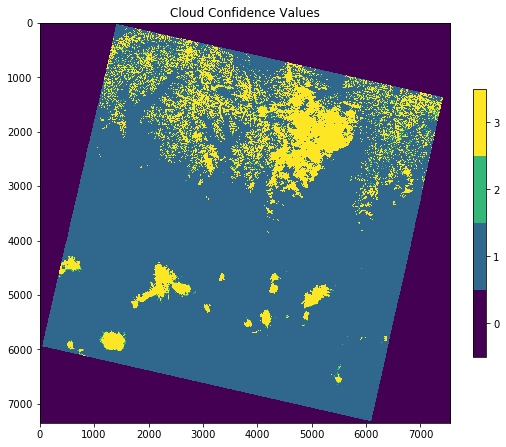

```python
cloud_confidence = unpackqa.unpack_to_array(img_qa_data,
                                              product=L8_qa_product,
                                              flags=['Cloud_Confidence'])

quick_raster_plot(cloud_confidence, title = 'Cloud Confidence Values', unique_values=[0,1,2,3], legend=True)
```

If you need several masks for different purposes it would be useful to be able to reference them directly.  
For example, say you want to mask out cloudy pixels, but you also want the water mask to highlight rivers or lakes.  
The `unpack_to_dict` function allows for easier separation to use flags later.

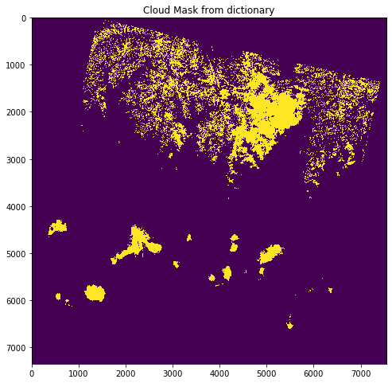

```python
masks = unpackqa.unpack_to_dict(img_qa_data,
                                  product=L8_qa_product,
                                  flags=['Cloud','Water'])

quick_raster_plot(masks['Cloud'], title='Cloud Mask from dictionary')
```

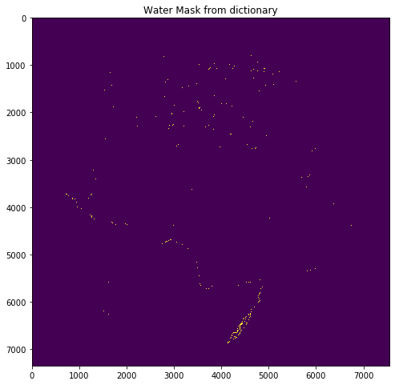

```python
plt.figure(figsize = (10,10))
quick_raster_plot(masks['Water'], title='Water Mask from dictionary')
```